# Salinity stress in Eruca sativa ((E. sativa) )

##### (2) Biomass

```r
a6 <- aov(Fresh_Weight ~ Treat_Contr, data = Weight_ion)
shapiro.test(a6$residuals)
```

```
##
##  Shapiro-Wilk normality test
##
## data:  a6$residuals
## W = 0.9122, p-value = 2.579e-07
```

```r
# no normality

a7 <- aov(Dry_Weight ~ Treat_Contr, data = Weight_ion)
shapiro.test(a7$residuals)
```

```
##
##  Shapiro-Wilk normality test
##
## data:  a7$residuals
## W = 0.91967, p-value = 7.184e-07
```

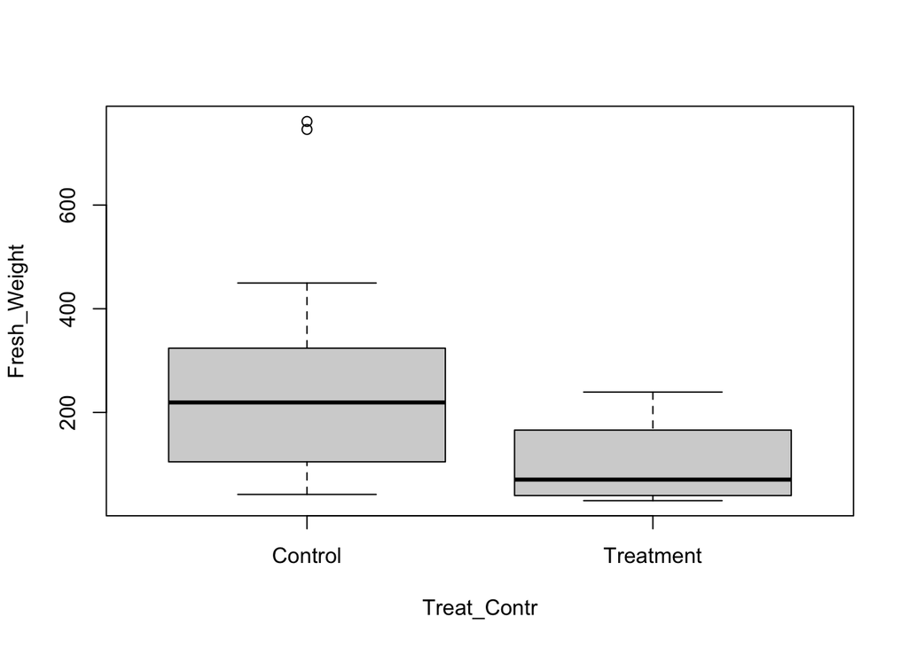

```
##
##  Kruskal-Wallis rank sum test
##
## data:  Weight_ion[, i] by Weight_ion$Treat_Contr
## Kruskal-Wallis chi-squared = 38.46, df = 1, p-value = 5.588e-10
```

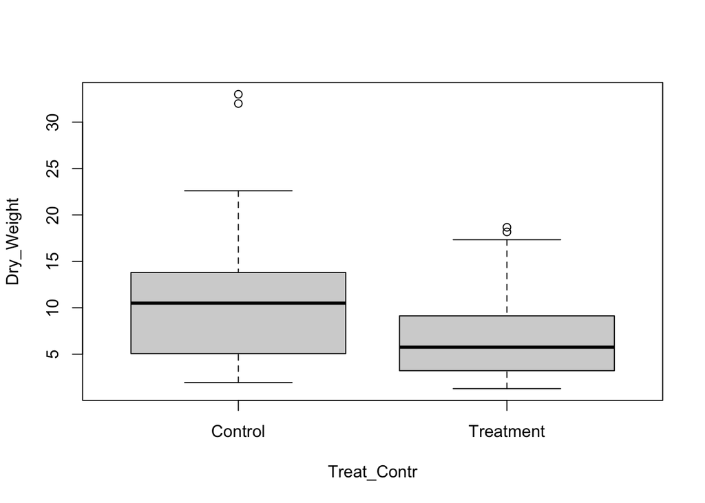

```
##
##  Kruskal-Wallis rank sum test
##
## data:  Weight_ion[, i] by Weight_ion$Treat_Contr
## Kruskal-Wallis chi-squared = 17.354, df = 1, p-value = 3.103e-05
```

```r
# no normality

for (i in names(Weight_ion[4:5])) {
  boxplot(Weight_ion[, i] ~ Weight_ion$Treat_Contr,
          ylab = names(Weight_ion[i]),
          xlab = names(Weight_ion[3])
  )
  print(kruskal.test(Weight_ion[, i] ~ Weight_ion$Treat_Contr))
}
```

- **Fresh weight (FW)**: Fresh weight is significantly reduced in the salt-stressed plants compared with the control (p < 0.05). The mean value for FW in salt-stressed plants 96.22 ± 66.00 and 241.06 ± 164.75 for control plants. FW stress index of accessions varied from 10.20 to 83.93
- **Dry weight (DW)**: Dry weight is significantly reduced in the salt-stressed plants compared with the control (p < 0.05). The mean value for DW in salt-stressed plants is 6.26 ± 4.00 and 10.58 ± 6.89 for control plants. DW stress index of accessions varied from 24.67 to 88.26

##### (3) RWC, EL and chlorophyll content

```r
a8 <- aov(RWC ~ Treat_Contr, data = Weight_ion)
shapiro.test(a8$residuals)
```

```
##
##  Shapiro-Wilk normality test
##
## data:  a8$residuals
## W = 0.7413, p-value = 4.475e-14
```

```r
# No normality

a9 <- aov(Electrolyte_Leakage ~ Treat_Contr, data = Weight_ion)
shapiro.test(a9$residuals)
```

```
##
##  Shapiro-Wilk normality test
##
## data:  a9$residuals
## W = 0.9626, p-value = 0.0009774
```

```r
# No normality

a10 <- aov( Chlorophyll_Content ~ Treat_Contr, data = Chloro_c)
shapiro.test(a10$residuals)
```

```
##
##  Shapiro-Wilk normality test
##
## data:  a10$residuals
## W = 0.89945, p-value = 3.166e-13
```

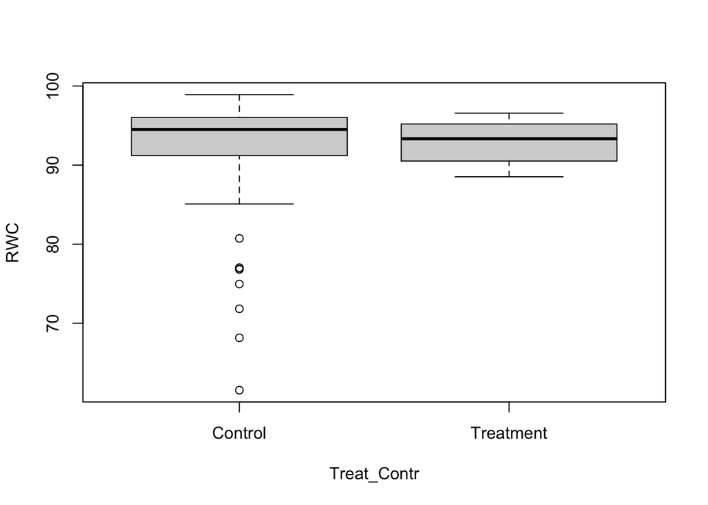

```
##
##  Kruskal-Wallis rank sum test
##
## data:  Weight_ion[, i] by Weight_ion$Treat_Contr
## Kruskal-Wallis chi-squared = 2.0921, df = 1, p-value = 0.1481
```

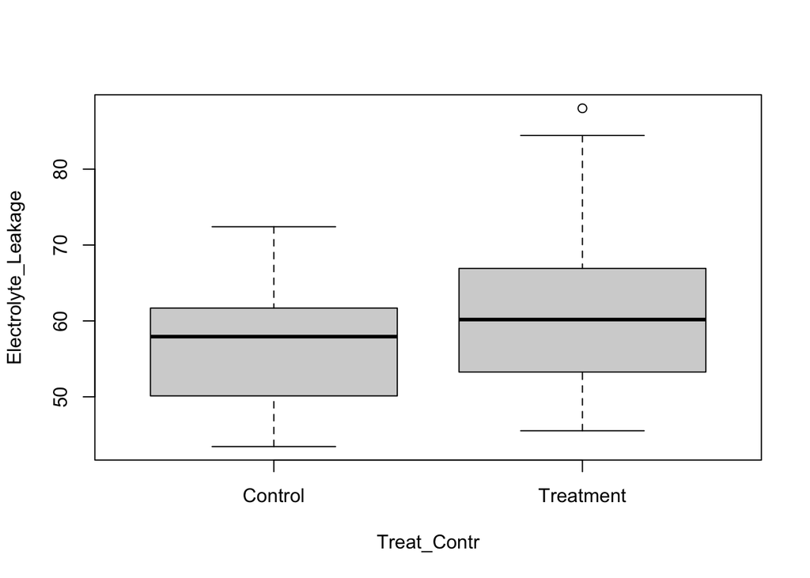

```
##
##  Kruskal-Wallis rank sum test
##
## data:  Weight_ion[, i] by Weight_ion$Treat_Contr
## Kruskal-Wallis chi-squared = 5.2837, df = 1, p-value = 0.02153
```

```r
# No normality

for (i in names(Weight_ion[c(6,12)])) {
  boxplot(Weight_ion[, i] ~ Weight_ion$Treat_Contr,
          ylab = names(Weight_ion[i]),
          xlab = names(Weight_ion[3])
  )
  print(kruskal.test(Weight_ion[, i] ~ Weight_ion$Treat_Contr))
}
```

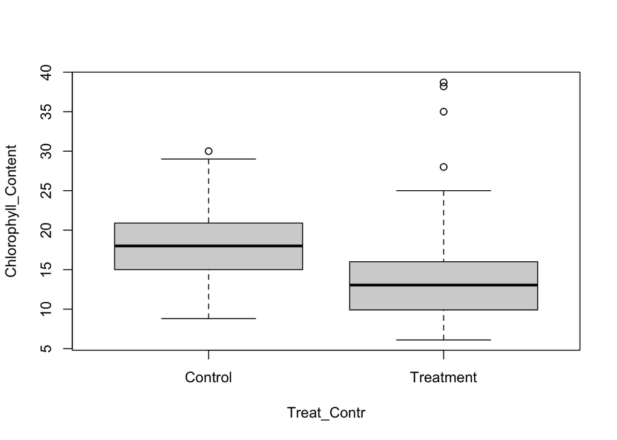

```
##
##  Kruskal-Wallis rank sum test
##
## data:  Chloro_c[, i] by Chloro_c$Treat_Contr
## Kruskal-Wallis chi-squared = 61.026, df = 1, p-value = 5.633e-15
```

```r
for (i in names(Chloro_c[4])) {
  boxplot(Chloro_c[, i] ~ Chloro_c$Treat_Contr,
          ylab = names(Chloro_c[i]),
          xlab = names(Chloro_c[3])
  )
  print(kruskal.test(Chloro_c[, i] ~ Chloro_c$Treat_Contr))
}
```

- **Relative water content (RWC)**: Relative water content is not significantly different in the salt-stressed plants compared with the control (p > 0.05). The mean value for RWC in salt-stressed plants 92.77 X ± 2.65 and 92.10 ± 7.00 for control plants.
- **Electrolyte leakage (EL)**: Electrolyte leakage is significantly increased in the salt-stressed plants compared with the control (p < 0.05). The mean value for EL in salt-stressed plants is 60.60 ± 9.32 and 56.51 ± 6.48 for control plants.
- **Chlorophyll content (CC)**: Chlorophyll content is significantly reduced in the salt-stressed plants compared with the control (p < 0.05). The mean value for CC in salt-stressed plants is 14.06 ± 6.02 and 18.17 ± 4.79 for control plants.